# Thursday

Shih-Ni Prim 2020-10-16

- Introduction
- Setting the Value for the Parameter
- Data
- Splitting Data
- Summaries and Exploratory Data Analysis
- Fitting models
  - Regression tree
  - Boosted Tree
  - Comparison
  - Final Model

## Introduction

Now we take a look at Thursday’s analysis. This dataset contains information about [bike sharing](https://archive.ics.uci.edu/ml/datasets/Bike+Sharing+Dataset). We have a variety of predictors, including hours, temperature, humidity, weekday, holiday/workday or not, etc. In our analysis, We will use two statistical learning models–regression tree and boosted tree–to predict the count of total rental bikes `cnt`.

## Setting the Value for the Parameter

Since the current analysis is on Thursday, we first find the corresponding value for it.

```r
set.seed(7777)
i <- 0:6
dayz <- c("Sunday", "Monday", "Tuesday", "Wednesday", "Thursday", "Friday", "Saturday")
df <- as.data.frame(cbind(i, dayz))
weekdayNum <- df$i[df$dayz == params$weekday]
print(weekdayNum)
```

```
## [1] "4"
```

## Data

Now we read in the data. Two datasets are listed on [the link](https://archive.ics.uci.edu/ml/datasets/Bike+Sharing+Dataset), one including the `hr` variable, and one treating each day as one observation and thus not including the `hr` variable. Since hours–the time in the day–should be a meaningful predictor for the number of bike rentals, we use the dataset with the `hr` variable

```r
bikes <- read_csv("../Bike-Sharing-Dataset/hour.csv")
# head(bikes)
analysis <- bikes %>% filter(weekday == weekdayNum) %>% select(-casual, -registered) %>% select(dteday, weekday, everything())
# head(analysis)
```

## Splitting Data

We first split up the data into two sets: training and test sets. The training set has about 70% of the data, and the test set has about 30%. Splitting up the data is important, because we want to test the model on a set that is not used in training, otherwise we risk overfitting.

```r
train <- sample(1:nrow(analysis), size = nrow(analysis)*0.7)
test <- setdiff(1:nrow(analysis), train)

bikeTrain <- analysis[train,]
bikeTest <- analysis[test,]
```

## Summaries and Exploratory Data Analysis

To decide which variables to include in our models, we first take a quick look at the data. We can look at summaries of numerical variables.

```r
summary(bikeTrain)
```

```
##      dteday              weekday     instant          season           yr
##  Min.   :2011-01-06   Min.   :4   Min.   :  116   Min.   :1.00   Min.   :0.0000
##  1st Qu.:2011-07-07   1st Qu.:4   1st Qu.: 4396   1st Qu.:2.00   1st Qu.:0.0000
##  Median :2011-12-29   Median :4   Median : 8584   Median :3.00   Median :0.0000
##  Mean   :2011-12-31   Mean   :4   Mean   : 8640   Mean   :2.51   Mean   :0.4945
##  3rd Qu.:2012-06-28   3rd Qu.:4   3rd Qu.:12951   3rd Qu.:3.00   3rd Qu.:1.0000
##  Max.   :2012-12-27   Max.   :4   Max.   :17283   Max.   :4.00   Max.   :1.0000
##       mnth              hr           holiday          workingday       weathersit
##  Min.   : 1.000   Min.   : 0.00   Min.   :0.00000   Min.   :0.0000   Min.   :1.000
##  1st Qu.: 4.000   1st Qu.: 6.00   1st Qu.:0.00000   1st Qu.:1.0000   1st Qu.:1.000
##  Median : 7.000   Median :11.00   Median :0.00000   Median :1.0000   Median :1.000
##  Mean   : 6.574   Mean   :11.51   Mean   :0.01793   Mean   :0.9821   Mean   :1.408
##  3rd Qu.: 9.000   3rd Qu.:17.00   3rd Qu.:0.00000   3rd Qu.:1.0000   3rd Qu.:2.000
##  Max.   :12.000   Max.   :23.00   Max.   :1.00000   Max.   :1.0000   Max.   :3.000
##       temp            atemp             hum           windspeed           cnt
##  Min.   :0.1000   Min.   :0.0758   Min.   :0.0000   Min.   :0.0000   Min.   :  1.0
##  1st Qu.:0.3400   1st Qu.:0.3333   1st Qu.:0.4700   1st Qu.:0.1045   1st Qu.: 44.0
##  Median :0.5200   Median :0.5000   Median :0.6100   Median :0.1940   Median :158.0
##  Mean   :0.5104   Mean   :0.4879   Mean   :0.6107   Mean   :0.1935   Mean   :197.8
##  3rd Qu.:0.6600   3rd Qu.:0.6212   3rd Qu.:0.7700   3rd Qu.:0.2836   3rd Qu.:277.0
##  Max.   :0.9400   Max.   :0.9242   Max.   :1.0000   Max.   :0.6866   Max.   :976.0
```

Below we look at three plots. The first plot shows the histogram of bike rentals (`cnt`) on Thursday. The second plot shows that `cnt` does vary in different hours. The third plot shows that `cnt` varies between the two years. So we know we should keep `hr` and `yr` as predictors.

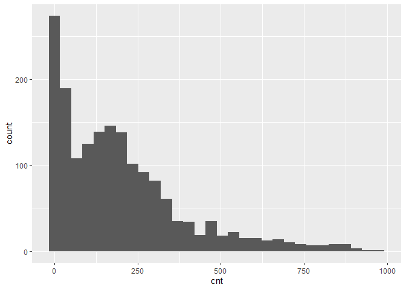

```r
ggplot(bikeTrain, mapping = aes(x = cnt)) + geom_histogram()
```

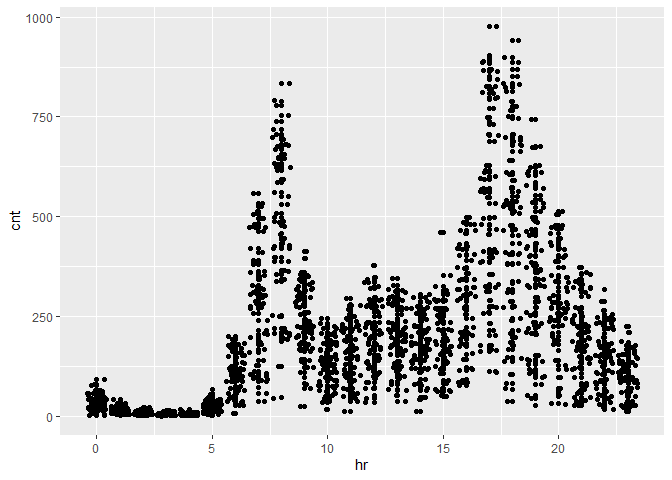

```r
ggplot(bikeTrain, aes(x = hr, y = cnt)) + geom_point() + geom_jitter()
```

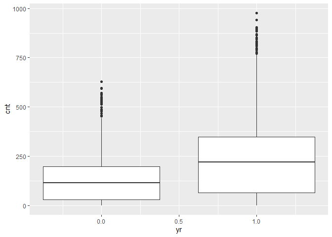

```r
ggplot(bikeTrain, aes(x = yr, y = cnt)) + geom_boxplot(aes(group = yr))
```

Next we look at correlations of different variables. Weather and windspeed do not seem correlate, so we will keep both `weathersit` and `windspeed`.

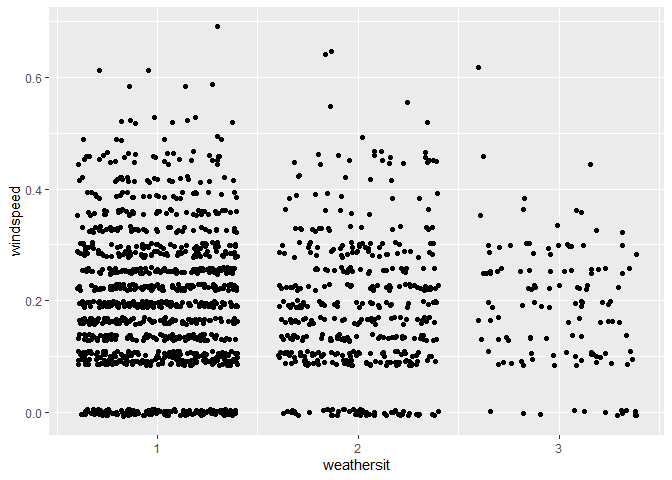

```r
ggplot(bikeTrain, aes(x = weathersit, y = windspeed)) + geom_jitter()
```

Several pairs of variables seem highly correlated–`season` and `mnth`, `holiday` and `workingday`–so we’ll remove one from each pair.

```r
cor(bikeTrain$season, bikeTrain$mnth)
```

```
## [1] 0.8203305
```

```r
cor(bikeTrain$holiday, bikeTrain$workingday)
```

```
## [1] -1
```

```r
cor(bikeTrain$temp, bikeTrain$atemp)
```

```
## [1] 0.9910297
```

The variance of `workingday` and `holiday` are too small and probably not good predictors.

```r
var(bikeTrain$holiday)
```

```
## [1] 0.01761816
```

```r
var(bikeTrain$workingday)
```

```
## [1] 0.01761816
```

Also, `instant` and `dteday` are for record-keeping. Thus, we decide to keep the following variables as the predictors: `season`, `yr`, `hr`, `weathersit`, `atemp`, `hum`, and `windspeed`.

```r
bikeTrain <- select(bikeTrain, season, yr, hr, weathersit, atemp, hum, windspeed, cnt)
bikeTest <- select(bikeTest, season, yr, hr, weathersit, atemp, hum, windspeed, cnt)
```

## Fitting models

Now we have a final training set and have chosen the predictors, we can use two models–regression tree and boosted tree–to fit the training data.

### Regression tree

A regression tree is one of the tree based methods for supervised learning with the goal of predicting a continuous response. It splits up predictor space into different regions, and the prediction of each region is often the mean of observations in that region.

```r
modelLookup("rpart")

bikeTree <- train(cnt ~ ., data = bikeTrain, method = "rpart", trControl = trainControl(method = "LOOCV"), tuneGrid = expand.grid(cp = seq(0.01, 0.02, 0.001)))
```

Below we can see the final model; the resulting RMSE, Rsquared, and MAE of different cp; and a plot that shows the relationship between cp and RMSE.

```r
bikeTree$finalModel
```

```
## n= 1729
##
## node), split, n, deviance, yval
##       * denotes terminal node
##
##   1) root 1729 61651110.0 197.75940
##     2) hr< 6.5 494   833934.4  30.82794 *
##     3) hr>=6.5 1235 41544970.0 264.53200
##       6) yr< 0.5 618  9080075.0 188.99510
##        12) atemp< 0.44695 257  2069753.0 128.89880 *
##        13) atemp>=0.44695 361  5421372.0 231.77840
##          26) hr< 15.5 194  1263195.0 188.01550
##            52) hr>=8.5 163   294056.8 161.11660 *
##            53) hr< 8.5 31   231069.7 329.45160 *
##          27) hr>=15.5 167  3355011.0 282.61680
##            54) hr>=20.5 52   140762.7 153.78850 *
##            55) hr< 20.5 115  1960979.0 340.86960 *
##       7) yr>=0.5 617 25406800.0 340.19120
##        14) hr>=20.5 106   812800.7 185.63210 *
##        15) hr< 20.5 511 21536540.0 372.25240
##          30) hr< 16.5 362  8087357.0 299.96960
##            60) hr>=8.5 291  2247388.0 249.26120 *
##            61) hr< 8.5 71  2024887.0 507.80280
##             122) hr< 7.5 34   496272.5 385.47060 *
##             123) hr>=7.5 37   552238.3 620.21620 *
##          31) hr>=16.5 149  6962641.0 547.86580
##            62) atemp< 0.47725 50  1219650.0 349.92000 *
##            63) atemp>=0.47725 99  2794407.0 647.83840
##             126) hr>=18.5 44   343906.4 495.88640 *
##             127) hr< 18.5 55   621819.2 769.40000 *
```

```r
bikeTree
```

```
## CART
##
## 1729 samples
##    7 predictor
##
## No pre-processing
## Resampling: Leave-One-Out Cross-Validation
## Summary of sample sizes: 1728, 1728, 1728, 1728, 1728, 1728, ...
## Resampling results across tuning parameters:
##
##   cp     RMSE       Rsquared   MAE
##   0.010   88.47565  0.7805332  62.17621
##   0.011   89.10008  0.7774511  62.41517
##   0.012   91.33285  0.7661725  64.65007
##   0.013   90.83635  0.7686618  63.91590
##   0.014   91.08441  0.7673985  64.02656
##   0.015   92.26546  0.7614277  64.41892
##   0.016   94.78876  0.7483165  66.39899
##   0.017  100.26266  0.7183485  71.09874
##   0.018   99.71825  0.7213088  70.90109
##   0.019  102.74885  0.7042953  71.86475
##   0.020  102.74885  0.7042953  71.86475
##
## RMSE was used to select the optimal model using the smallest value.
## The final value used for the model was cp = 0.01.
```

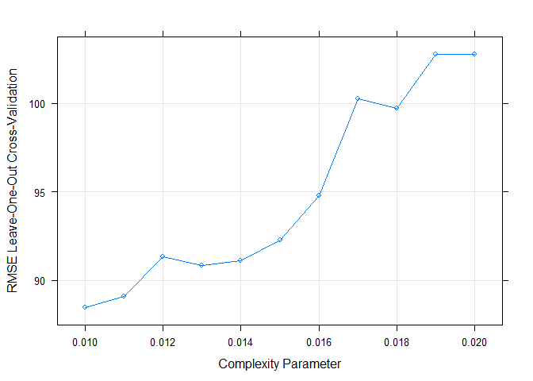

```r
plot(bikeTree)
```

Finally we use the model to predict `cnt` on the test data and calculate RMSE to check the fit of the model.

```r
predTree <- predict(bikeTree, newdata = bikeTest)
treeResult <- postResample(predTree, bikeTest$cnt)
```

### Boosted Tree

A boosted tree is one of the ensemble learning methods, in which the tree grows sequentially. Each subsequent tree is combined into the previous model to produce a modified model. The predictions are updated as the tree grows.

```r
modelLookup("gbm")

grid <- expand.grid(n.trees = c(50, 100, 150), interaction.depth = 1:4, shrinkage = c(0.1, 0.01), n.minobsinnode = c(10, 15, 20))

boostedBike <- train(cnt ~  season + yr + hr + weathersit + atemp + hum + windspeed, data = bikeTrain, method = "gbm", preProcess = c("center", "scale"), trControl = trainControl(method = "repeatedcv", number = 10, repeats = 3), tuneGrid = grid, verbose = FALSE)
```

Below we can see some information about the final model, the predictors chosen and their importance, and a plot that shows how RMSE changes with different numbers of boosting iterations and tree depths.

```r
boostedBike$finalModel
```

```
## A gradient boosted model with gaussian loss function.
## 150 iterations were performed.
## There were 7 predictors of which 7 had non-zero influence.
```

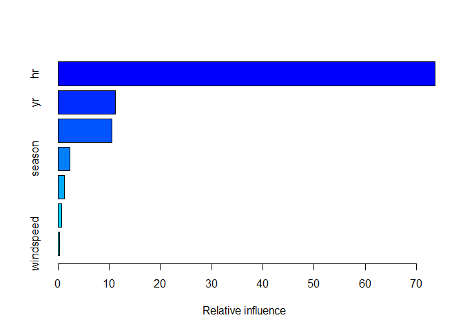

```r
summary(boostedBike)
```

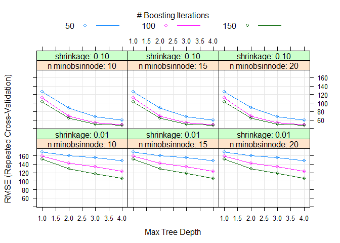

```r
plot(boostedBike)
```

Finally, we use the model to predict `cnt` on the test data and calculate RMSE to check the fit of the model.

```r
predBoostedBike <- predict(boostedBike, newdata = select(bikeTest, -cnt))
boostedResult <- postResample(predBoostedBike, bikeTest$cnt)
```

### Comparison

We can put the testing RMSE from the two models together for comparison.

```r
comparison <- data.frame(rbind(t(treeResult), t(boostedResult)))
colnames(comparison) <- c("RMSE", "Rsquared", "MAE")
rownames(comparison) <- c("Regression Tree", "Boosted Tree")
knitr::kable(comparison)
```

|  | RMSE | Rsquared | MAE |
| --- | --- | --- | --- |
| Regression Tree | 88.51060 | 0.7737665 | 62.85053 |
| Boosted Tree | 51.17239 | 0.9243865 | 30.14302 |

### Final Model

```r
# a function to generate the name of the best model
model <- function(x, y){
  xscore <- 0
  if (x[[1]] < y[[1]]) {
    xscore = xscore + 1
  }
  if (x[[2]] > y[[2]]){
    xscore = xscore + 1
  }
  if (x[[3]] < y[[3]]){
    xscore = xscore + 1
  }
  if (xscore == 2 || xscore == 3){
    final <- c("regression tree")
  } else {
    final <- c("boosted tree")
  }
  return(final)
}
# model(treeResult, boostedResult)
```

From the output, we can conclude that the boosted tree is the better model for Thursday data, because it has better performance in terms of RMSE, Rsquared, and MAE.